# 臺中市近四年空氣品質指數AQI之數據探討

# 學號：G08587109

# 2019/12/3

# 壹、前言與背景

2015年至2018年的臺中，悄悄擊敗過往的高雄從第三大都市躍升為台灣第二都市。當這美稱成為臺中人自豪與驕傲的同時，經濟發展與環境議題便漸漸浮上檯面，成為市民關注的焦點。臺中市民如今最在意的便是現今的空氣汙染問題。

2015-2018這四年間，臺中市的市民明顯的感受到空氣品質的下降，而許多報章媒體指出，在林佳龍市長執政時期，空氣品質下降的幅度最為明顯，2018年的選戰，現任市長盧秀燕也提出空汙一問題在選戰中直搗欲連任市長的林佳龍在臺中執政時未給予市民良好的空氣品質。 因此，在眾多聲浪與輿論的營造下，也帶給市民思考環境問題的重要性。在此思潮逐漸興起的過程裡，筆者嘗試在空氣品質的議題上進行數據分析探索，究竟臺中市的空氣汙染源自於何處？哪些汙染源影響市民的日常？空氣汙染可以改善嗎？應該如何改善？如果不能改善，則理由為何？

# 貳、資料來源與資料說明

### 一、資料來源：

本專題的資料報告來源主要為「民生物聯網」上的「國家空品測站」，將2015-2018年間的測站數據彙整成一個檔案。 (資料網址:https://ci.taiwan.gov.tw/dsp/environmental.aspx)

### 二、AQI指數：

參與評價的汙染源為SO2、NO2、PM10、PM2.5、O3、CO，六項進行計算。

### 三、研究限制：

● 決定臺中的五支測站：山、海、屯、市區

山線豐原EPA028（243）、海線沙鹿EPA029（244）、屯區大里EPA030（245）、市區忠明EPA031（246）、市區西屯EPA032（247）

● 選定AQI指數的汙染指標 :

SO2、NO2、PM10、PM2.5、O3、CO

● 選定時間限制:

### 四、由於每年的資料數不同，故此資料分析出的問題與結論均建立在資料支持的數據之上。

# 參、研究問題

1.臺中市近四年的空氣品質STATUS狀態分析，各項分別有多少比例？

2.統計在POLLUTANT欄位中主要汙染源最多者為哪一個汙染源，約占比例多少？

3.懸浮微粒PM2.5為主要汙染源的紀錄次數有多少？占了總紀錄次數的多少？

4.空氣污染物是個具有怎麼樣特性的資料？

5.六大污染氣體中2015-2018的汙染各年平均值為何？有多少數據量是大於此平均值的？

6.六大汙染源中，高於平均值的天數比例是否有逐年增加的趨勢？

7.從2015-2018年的空氣品質數據中，六大污染源的數據是否有上升的趨勢？哪些有上升哪些沒有上升？

8.五個測站分別代表臺中的山海屯與市區，其中懸浮微粒PM2.5的數據高低是否與環境有關？

9.山海屯市區的五支測站周圍是否有汙染工廠，如焚化廠、火力發電廠？

10.據箱型圖顯示，山線豐原測站與海線沙鹿測站在數據上有差異，而豐原的PM2.5汙染程度卻比沙鹿值高，試比較其他汙染物在這兩個測站上的數據差異。

# 肆、問題分析與解答

# 匯入所需套件

pip3 install folium # 安裝 Folium package

pip3 install seaborn # 安裝 Seaborn package

# 進行初步資料清洗

```python
#第一部分:清理基本資料2015-2018年總資訊
import os #匯入os套件
os.chdir(r'C:\Users\user\Desktop\學業\空氣品質\林佳龍時期\之前')#匯入檔案位置
os.getcwd()
import pandas as pd
df = pd.read_csv("2015-2018年空氣品質.csv","rb")#讀進要整理的資料
df2 = df.drop(["SO2_UNIT","CO_UNIT","O3_UNIT","PM10_UNIT","PM25_UNIT","NO2_UNIT","WINDSPEED_UNIT","WINDDIREC_UNIT",
               "TRANSACTIONID","ISCONVERTED","AQI","O3_8HR","UNIT","CO_8HR","PM10_AVG","PM25_AVG","NOX","NO_VALUE",
               "WINDSPEED","WINDDIREC","FPMI","UPDATETIME","FID","COUNTYID"])#刪除不必要的欄位

df_sample = df2[df2.SITEID.isin(["243","244","245","246","247"])]#留下要探討的測站
print(df_sample.head(5))
```

```python
#第二部分：制定日期格式、排序日期
import os #匯入os套件
os.chdir(r'C:\Users\user\Desktop\學業\空氣品質\林佳龍時期')　#匯入檔案位置
os.getcwd()
import pandas as pd
df = pd.read_excel("2015-2018台中國家空氣品質測站整理.xlsx").astype(str)
date = df.DATACREATIONDATE　#抓出DATACREATIONDATE的欄位並刪除空值

def item_transfer(x):　#定義資料清洗工具轉換
    global years　#宣告years為全域變數
    global month　#宣告month全域變數
    a = x.replace('月','')　#清洗掉DATACREATIONDATE的"月"字串
    b = a.replace('-','')　#清洗a
    i = b.replace(' ','')　#清洗b資料,變成五位數或六位數
    if i[-2:] == '14':　#如果數值倒數第二項為15
        years = i[-2:].replace('14','2014')　#那麼年替換為2014
    elif i[-2:] == '15':　#如果數值倒數第二項為18
        years = i[-2:].replace('15','2015')　#那麼年替換為2015
    elif i[-2:] == '16':　#如果數值倒數第二項為16
        years = i[-2:].replace('16','2016')　#那麼年替換為2016
    elif i[-2:] == '17':　#如果數值倒數第二項為17
        years = i[-2:].replace('17','2017')　#那麼年替換為2017
    elif i[-2:] == '18':　#如果數值倒數第二項為18
        years = i[-2:].replace('18','2018')　#那麼年替換為2018
    day = i[0:2]　#指定天為i的一到三位
    if len(i) == 5:　#如果資料是五位數
        zero = "0"
        month = zero + i[2]　#就算到第三個
    elif len(i) == 6:　#如果資料是六位數
        month = i[2:4]　#就算第三個與第四個
    s = [years, month, day]　#將年月日轉換成清單
    strl = "-"　#要帶入的格式字串
    y = strl.join(s)　#帶入字串進去清單S
    return y　#傳回結果的Y值

df["DATE"] = pd.Series([item_transfer(date[x]) for x in range(len(date))]).values　#建立一個DATE的欄位，並輸入所有經過轉換函式的資料
df2 = df.set_index("DATE")
df2.sort_index(ascending=True,inplace=True)
df_final = df2.drop(["DATACREATIONDATE",
          "NO"],axis=1)
df_final.to_excel('2014年8月-2018年8月台中國家空氣品質測站整理2.xlsx')#轉存進原檔裡

print(df_final.head(5))
```

```
           SITEID   PSI POLLUTANT STATUS  SO2    CO    O3  PM10  PM25  NO2
DATE
2014-08-31    247  41.0       nan     良好  2.0  0.19  49.0  26.0  15.0  6.2
2014-08-31    246  45.0       nan     良好  3.2  0.24  54.0  27.0  15.0  7.0
2014-08-31    243  42.0       nan     良好  1.7  0.26  50.0  22.0  24.0  6.7
2014-08-31    244  46.0       nan     良好  3.6  0.21  55.0  34.0  17.0  7.3
2014-08-31    245  41.0       nan     良好  2.3  0.19  49.0  36.0  12.0  4.5
```

# 1.臺中市近四年的空氣品質STATUS狀態分析，各項分別有多少比例？

```python
#第一步驟：明確查詢空氣品質STATUS有哪幾種狀態
import os
os.chdir(r'C:\Users\user\Desktop\學業\空氣品質\林佳龍時期')
os.getcwd()
import pandas as pd
df = pd.read_excel("2014年8月-2018年8月台中國家空氣品質測站整理2.xlsx")#引入整理過的資料檔

from collections import Counter #引入計算工具
a = df.STATUS.dropna() #丟掉空值
b = Counter(a) # 計算丟掉空值的Dataframe
for STATUS, 數量 in b.items():
    print( "%s:%d 次" % (STATUS ,數量 )) #使用for迴圈計算不同的狀態有幾次
```

```
良好:198111 次
普通:138911 次
不良:258 次
對敏感族群不良:9934 次
對所有族群不良:1030 次
設備維護:1576 次
對敏感族群不健康:6691 次
對所有族群不健康:1294 次
```

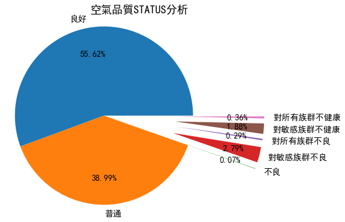

```python
#第二步驟：顯示汙染源空氣品質STATUS及其比例
import os
os.chdir(r'C:\Users\user\Desktop\學業\空氣品質\林佳龍時期')
os.getcwd()
import pandas as pd
df = pd.read_excel("2014年8月-2018年8月台中國家空氣品質測站整理2.xlsx")#引入整理過的資料檔
%matplotlib inline
import matplotlib.pyplot as plt
from matplotlib import pyplot as plt
plt.rcParams['font.sans-serif']=['SimHei'] #顯示中文

#計算各個項目的次數
a = len(df[df.STATUS == "良好"])
b = len(df[df.STATUS == "普通"])
c = len(df[df.STATUS == "不良"])
d = len(df[df.STATUS == "對敏感族群不良"])
e = len(df[df.STATUS == "對所有族群不良"])
f = len(df[df.STATUS == "對敏感族群不健康"])
g = len(df[df.STATUS == "對所有族群不健康"])
ratings = [a, b, c, d, e, f, g]
all = sum(ratings) #相加所有ratings的值

#取數值到小數點第二位
a1 = round(a / all *100 , 2)
b1 = round(b / all *100 , 2)
c1 = round(c / all *100 , 2)
d1 = round(d / all *100 , 2)
e1 = round(e / all *100 , 2)
f1 = round(f / all *100 , 2)
g1 = round(g / all *100 , 2)

plt.figure(figsize=(8,6))
labels = [u"良好",
          u"普通",
          u"不良",
          u"對敏感族群不良",
          u"對所有族群不良",
          u"對敏感族群不健康",
          u"對所有族群不健康"]
ratings = [a1, b1, c1, d1, e1, f1, g1]
all = sum(ratings) #相加所有ratings的值
explode = (0, 0, 0.8, 0.8, 0.8, 0.8,0.8) #指定哪幾個圓餅圖的項目要拉出來

patch, texts1,texts2 = plt.pie(ratings,
        labels=labels,
        explode=explode,
        autopct = '%3.2f%%',
        textprops = {"fontsize" :14},
        pctdistance = 0.7) #圓餅圖的各項設定

plt.title("空氣品質STATUS分析",{"fontsize" : 18}) #指定標題及標題大小
plt.axis("equal")
plt.show()
```

## 答:

如上圖所示。

# 2.統計在POLLUTANT欄位中主要汙染源最多者為哪一個汙染源，約占比例多少？

```python
#第一步驟：明確查詢有哪幾種汙染源
import os
os.chdir(r'C:\Users\user\Desktop\學業\空氣品質\林佳龍時期')
os.getcwd()
import pandas as pd
df = pd.read_excel("2014年8月-2018年8月台中國家空氣品質測站整理2.xlsx")#引入整理過的資料檔

from collections import Counter #引入計算工具
a = df.POLLUTANT.dropna() #丟掉空值
b = Counter(a) # 計算丟掉空值的Dataframe
for POLLUTANT, 數量 in b.items():
    print( "%s:%d 次" % (POLLUTANT ,數量 )) #使用for迴圈計算不同的狀態有幾次
```

```
臭氧:10876 次
懸浮微粒:63096 次
一氧化碳:24 次
細懸浮微粒:78344 次
臭氧八小時:5764 次
二氧化硫:14 次
```

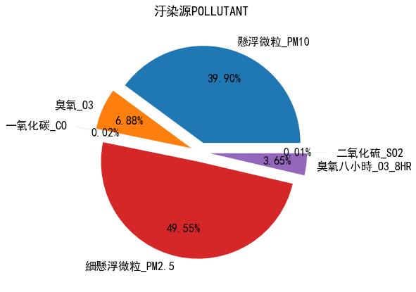

```python
#顯示汙染源POLLUTANT及其比例
import os
os.chdir(r'C:\Users\user\Desktop\學業\空氣品質\林佳龍時期')
os.getcwd()
import pandas as pd
df = pd.read_excel("2014年8月-2018年8月台中國家空氣品質測站整理2.xlsx")#引入整理過的資料檔
a = len(df[df.POLLUTANT == "懸浮微粒"])
b = len(df[df.POLLUTANT == "臭氧"])
c = len(df[df.POLLUTANT == "一氧化碳"])
d = len(df[df.POLLUTANT == "細懸浮微粒"])
e = len(df[df.POLLUTANT == "臭氧八小時"])
f = len(df[df.POLLUTANT == "二氧化硫"])

ratings = [a, b, c, d, e, f]
all = sum(ratings)

a1 = round(a / all *100 , 2)
b1 = round(b / all *100 , 2)
c1 = round(c / all *100 , 2)
d1 = round(d / all *100 , 2)
e1 = round(e / all *100 , 2)
f1 = round(f / all *100 , 2)

plt.rcParams['font.sans-serif']=['SimHei'] #顯示中文
plt.figure(figsize=(7,7))
labels = [u"懸浮微粒_PM10",
          u"臭氧_O3",
          u"一氧化碳_CO",
          u"細懸浮微粒_PM2.5",
          u"臭氧八小時_O3_8HR",
          u"二氧化硫_SO2"]
ratings = [a1, b1, c1, d1, e1, f1]
all = sum(ratings)
explode = (0.1, 0.1, 0.3, 0.1, 0.1, 0.3)

patch, texts1,texts2 = plt.pie(ratings,
        labels=labels,
        explode=explode,
        autopct = '%3.2f%%',
        textprops = {"fontsize" :16},
        pctdistance = 0.7)

plt.title(u"汙染源POLLUTANT",{"fontsize" : 18})
plt.axis("equal")
plt.show()
```

## 答:

PM2.5為最多的汙染源

# 3.懸浮微粒PM2.5為主要汙染源的數量有多少？占了總數量的多少？

```python
import os
os.chdir(r'C:\Users\user\Desktop\學業\空氣品質\林佳龍時期')
os.getcwd()
import pandas as pd
df = pd.read_excel("2014年8月-2018年8月台中國家空氣品質測站整理2.xlsx")#引入整理過的資料檔
a = len(df[df.POLLUTANT == "懸浮微粒"])

print("共計:",a ,"次" )
```

```
共計: 63096 次
```

# 4.空氣污染物是個具有怎麼樣特性的資料?

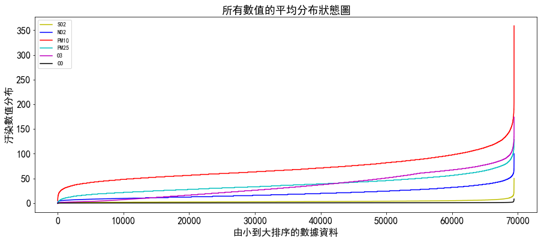

```python
import os
os.chdir(r'C:\Users\user\Desktop\學業\空氣品質\林佳龍時期')
os.getcwd()
import pandas as pd
df = pd.read_excel("2014年8月-2018年8月台中國家空氣品質測站整理2.xlsx").dropna()#引入整理過的資料檔#引進資料

#數值折現圖呈現，x軸是所有數據的依低到高排序（不計時間），Y軸是數據的
import numpy as np
SO2 = df.SO2.dropna()#Y軸的數據
list_SO2 = sorted(SO2) #排序資料
NO2 = df.NO2.dropna()#Y軸的數據
list_NO2 = sorted(NO2) #排序資料
PM10 = df.PM10.dropna()#Y軸的數據
list_PM10 = sorted(PM10) #排序資料
PM25 = df.PM25.dropna()#Y軸的數據
list_PM25 = sorted(PM25) #排序資料
O3 = df.O3.dropna()#Y軸的數據
list_O3 = sorted(O3) #排序資料
CO = df.CO.dropna()#Y軸的數據
list_CO = sorted(CO) #排序資料
condition = np.arange(len(df.dropna()))#X軸的數據
import matplotlib.pyplot as plt
plt.rcParams['font.sans-serif']=['SimHei'] #顯示中文
plt.figure(figsize=(15,6))
plt.title("所有數值的平均分布狀態圖",fontsize = 18) #顯示標題
plt.plot(condition, list_SO2 , 'y-',label="SO2")
plt.plot(condition, list_NO2 , 'b-',label="NO2")
plt.plot(condition, list_PM10 , 'r-',label="PM10")
plt.plot(condition, list_PM25 , 'c-',label="PM25")
plt.plot(condition, list_O3 , 'm-',label="O3")
plt.plot(condition, list_CO , 'k-',label="CO")
plt.xlabel("由小到大排序的數據資料",fontsize = 16) #X軸的標籤
plt.ylabel("汙染數值分布",fontsize = 16) #Y軸的標籤
plt.xticks(fontsize = 16) #指定X軸的字體大小
plt.yticks(fontsize = 16) #指定Y軸的字體大小
plt.legend(loc = 0) #指定圖例坐落位置
plt.show()
#SO2:y、NO2:b、PM10:r、PM25:c、O3:m、CO:k
```

```
([], <a list of 0 Text xticklabel objects>)
```

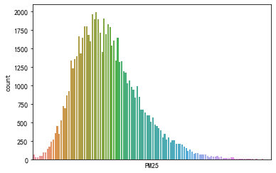

```python
%matplotlib inline
import os
os.chdir(r'C:\Users\user\Desktop\學業\空氣品質\林佳龍時期')
os.getcwd()
import pandas as pd
df = pd.read_excel("2014年8月-2018年8月台中國家空氣品質測站整理2.xlsx").dropna()
SO2 = df.SO2.dropna()#Y軸的數據
NO2 = df.NO2.dropna()#Y軸的數據
PM10 = df.PM10.dropna()#Y軸的數據
PM25 = df.PM25.dropna()#Y軸的數據
O3 = df.O3.dropna()#Y軸的數據
CO = df.CO.dropna()#Y軸的數據
import seaborn as sns #引入seaborn套件
import pandas as pd #引入pandas套件
import matplotlib.pyplot as plt #引入matplotlib套件

#以下為各污染源數值，以Dataframe呈現
cyl_SO2 = pd.DataFrame({"SO2": SO2})
cyl_NO2 = pd.DataFrame({"NO2": NO2})
cyl_PM10 = pd.DataFrame({"PM10": PM10})
cyl_PM25 = pd.DataFrame({"PM25": PM25})
cyl_O3 = pd.DataFrame({"O3": O3})
cyl_CO = pd.DataFrame({"CO": CO})

#由於數值分布情況類似，故以PM2.5作為代表
sns.countplot(x="PM25", data=cyl_PM25) #直接以countplot功能計算PM2.5數值分布與計次
plt.xticks([]) #不顯示x軸
```

## 答:

最大值數量少、數值極高， 最小值非常少，中間分布平緩上升的數值

如在分布圖上，是個中位數偏低的數據。

可以解釋空氣汙染為一種汙染感受度明顯的汙染(單日單時排放量差距量可以很大)，且六種數據都有這樣的特質。

# 5.六大污染氣體中2015-2018的汙染各年平均值為何？有多少數據量是大於此平均值的？

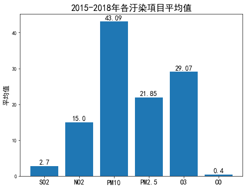

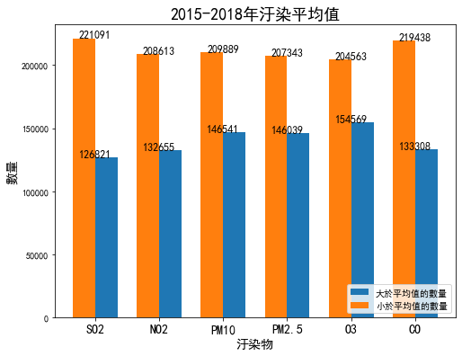

```python
#2015-2018年的SO2、NO2、PM10、PM2.5、O3、CO各項平均值
import os
os.chdir(r'C:\Users\user\Desktop\學業\空氣品質\林佳龍時期')
os.getcwd()
import pandas as pd
import numpy as np
plt.rcParams['font.sans-serif']=['SimHei'] #顯示中文
df = pd.read_excel("2014年8月-2018年8月台中國家空氣品質測站整理2.xlsx")#引入整理過的資料檔

SO2 = sum(df.SO2.dropna())/len(df.SO2.dropna())
NO2 = sum(df.NO2.dropna())/len(df.NO2.dropna())
PM10 = sum(df.PM10.dropna())/len(df.PM10.dropna())
PM25 = sum(df.PM25.dropna())/len(df.PM25.dropna())
O3 = sum(df.O3.dropna())/len(df.O3.dropna())
CO = sum(df.CO.dropna())/len(df.CO.dropna())

a = round(SO2,2) #計算到小數點第二位
b = round(NO2,2)
c = round(PM10,2)
d = round(PM25,2)
e = round(O3,2)
f = round(CO,2)

plt.figure(figsize=(8,6)) #指定圖的大小
rating = [a, b ,c ,d ,e, f] #數據
labels = ["SO2","NO2","PM10","PM2.5","O3","CO"] #標籤
index = np.arange(len(labels)) #總共有多少數據
plt.rcParams['font.sans-serif']=['SimHei'] #顯示中文
plt.bar(index,rating) #圖資的兩軸數據
plt.xticks(index,
           labels,fontsize=14)
plt.ylabel(u"平均值",fontsize=14)
plt.title(u"2015-2018年各汙染項目平均值",{"fontsize" : 18})
for x,y in enumerate(rating): #調整圖形數值顯示
    plt.text(x,y+0.5,'%s' %y,ha='center',fontsize=14)
plt.show()

#有多少數據量是大於此平均值的？
import numpy as np
labels = ["SO2",
          "NO2",
          "PM10",
          "PM2.5",
          "O3",
          "CO"]
ratings = [sum(df.SO2.dropna() > 2.7),
          sum(df.NO2.dropna() > 15.0),
          sum(df.PM10.dropna() > 43.09),
          sum(df.PM25.dropna() > 21.85),
          sum(df.O3.dropna() > 29.07),
          sum(df.CO.dropna() > 0.4)]

change = [sum(df.SO2.dropna() < 2.7),
          sum(df.NO2.dropna() < 15.0),
          sum(df.PM10.dropna() < 43.09),
          sum(df.PM25.dropna() < 21.85),
          sum(df.O3.dropna() < 29.07),
          sum(df.CO.dropna() < 0.4)]

plt.figure(figsize=(8,6))
plt.bar(labels,
        ratings,
        label = u"大於平均值的數量",
        align = "edge",
        width = 0.35,)
plt.bar(labels,
        change,
        label = u"小於平均值的數量",
        align = "edge",
        width = -0.35)
plt.legend(loc = 4) #要使用label要加這行
plt.title("2015-2018年汙染平均值",{"fontsize" : 18})
plt.xlabel(u"汙染物",fontsize=14)
plt.ylabel(u"數量",fontsize=14)
plt.xticks(labels,fontsize=14)
for x,y in enumerate(ratings):
    plt.text(x,y+170,'%s' %y,ha='center',fontsize=12) #調整數值呈現位置
for x,y in enumerate(change):
    plt.text(x,y+220,'%s' %y,ha='center',fontsize=12) #調整數值呈現位置
```

# 6.六大汙染源中，高於平均值的天數比例是否有逐年增加的趨勢？

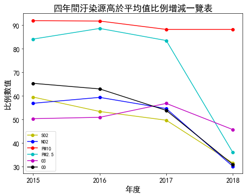

```python
import os
os.chdir(r'C:\Users\user\Desktop\學業\空氣品質\林佳龍時期')
os.getcwd()

#引入平均值的數據 SO2:"2.7ppb"、NO2:"15ppb"、PM10:"43.09μg/m3"、PM2.5:"21.85μg/m3"、O3:"29.07ppb"、CO:"0.4ppm"
#2015年的各項污染高於平均值的天數比例
import pandas as pd #先引進數據
df1 = pd.read_excel("2015台中國家空氣品質測站整理.xlsx").dropna()#引入整理過的資料檔

#計算2015年的值數目佔了多少比例
a1 = round(len(df1[df1.SO2 > 2.7]) / len(df1.SO2) *100 ,2)
b1 = round(len(df1[df1.NO2 > 15]) / len(df1.NO2) *100 ,2)
c1 = round(len(df1[df1.PM10 > 43.09]) / len(df1.PM10) *100 ,2)
d1 = round(len(df1[df1.PM25 > 21.85]) / len(df1.PM25) *100 ,2)
e1 = round(len(df1[df1.O3 > 29.07]) / len(df1.O3) *100 ,2)
f1 = round(len(df1[df1.CO > 0.4]) / len(df1.CO) *100 ,2)

#計算2016的值數目佔了多少比例
import pandas as pd #先引進數據
df2 = pd.read_excel("2016台中國家空氣品質測站整理.xlsx").dropna()#引入整理過的資料檔

a2 = round(len(df2[df2.SO2 > 2.7]) / len(df2.SO2)*100 ,2)
b2 = round(len(df2[df2.NO2 > 15]) / len(df2.NO2)*100 ,2)
c2 = round(len(df2[df2.PM10 > 43.09]) / len(df2.PM10)*100 ,2)
d2 = round(len(df2[df2.PM25 > 21.85]) / len(df2.PM25)*100 ,2)
e2 = round(len(df2[df2.O3 > 29.07]) / len(df2.O3)*100 ,2)
f2 = round(len(df2[df2.CO > 0.4]) / len(df2.CO)*100 ,2)

#計算2017的值數目佔了多少比例
import pandas as pd #先引進數據
df3 = pd.read_excel("2017台中國家空氣品質測站整理.xlsx").dropna()#引入整理過的資料檔

a3 = round(len(df3[df3.SO2 > 2.7]) / len(df3.SO2)*100 ,2)
b3 = round(len(df3[df3.NO2 > 15]) / len(df3.NO2)*100 ,2)
c3 = round(len(df3[df3.PM10 > 43.09]) / len(df3.PM10)*100 ,2)
d3 = round(len(df3[df3.PM25 > 21.85]) / len(df3.PM25)*100 ,2)
e3 = round(len(df3[df3.O3 > 29.07]) / len(df3.O3)*100 ,2)
f3 = round(len(df3[df3.CO > 0.4]) / len(df3.CO)*100 ,2)

#計算2018的值數目佔了多少比例
import pandas as pd #先引進數據
df4 = pd.read_excel("2018台中國家空氣品質測站整理.xlsx")#引入整理過的資料檔

a4 = round(len(df4[df4.SO2 > 2.7]) / len(df4.SO2)*100 ,2)
b4 = round(len(df4[df4.NO2 > 15]) / len(df4.NO2)*100 ,2)
c4 = round(len(df4[df4.PM10 > 43.09]) / len(df4.PM10)*100 ,2)
d4 = round(len(df4[df4.PM25 > 21.85]) / len(df4.PM25)*100 ,2)
e4 = round(len(df4[df4.O3 > 29.07]) / len(df4.O3)*100 ,2)
f4 = round(len(df4[df4.CO > 0.4]) / len(df4.CO)*100 ,2)

SO2 = [a1, a2, a3, a4]
NO2 = [b1, b2, b3, b4]
PM10 = [c1, c2, c3, c3]
PM25 = [d1, d2, d3, d4]
O3 = [e1, e2, e3, e4]
CO = [f1, f2, f3, f4]

time = ["2015", "2016", "2017", "2018"]
import matplotlib.pyplot as plt
%matplotlib inline
plt.rcParams['font.sans-serif']=['SimHei'] #顯示中文
plt.figure(figsize=(8,6)) #指定圖形大小
plt.title("四年間汙染源高於平均值比例增減一覽表",fontsize = 18) #顯示標題
plt.xlabel("年度",fontsize = 16) #顯示x軸標籤
plt.ylabel("比例數值",fontsize = 16) #顯示Y軸標籤
plt.plot(time, SO2, "y-o",label="SO2") #SO2的線圖
plt.plot(time, NO2, "b-o",label="NO2") #NO2的線圖
plt.plot(time, PM10,"r-o",label="PM10") #PM10的線圖
plt.plot(time, PM25,"c-o",label="PM2.5") #PM2.5的線圖
plt.plot(time, O3,"m-o",label="O3") #O3的線圖
plt.plot(time, CO,"k-o",label="CO") #CO的線圖
plt.xticks(fontsize = 14) #指定X軸字體大小
plt.yticks(fontsize = 14) #指定Y軸字體大小
plt.legend(loc = 3) #圖例的位置指定
plt.show()

#比對高於平均值的數據有多少天
#統計出2015、2016、2017、2018四年的單一數據，做出折線圖，六個數據用不同的顏色顯示在同一張圖上；SO2:y、NO2:b、PM10:r、PM25:c、O3:m、CO:k
```

## 答:

整體而言，由2017-2018年間，汙染源高於平均值的天數是有下降的趨勢，反倒沒有持續增加。

# 7.從2015-2018年的空氣品質數據中，六大污染源的數據是否有上升的趨勢？哪些有上升哪些沒有上升？

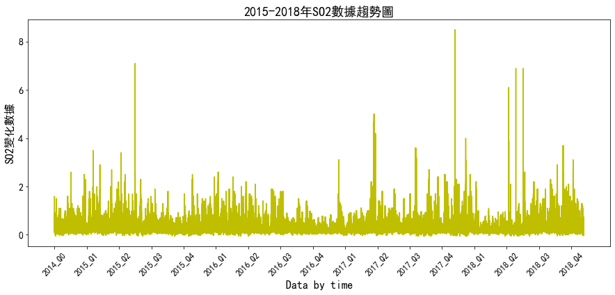

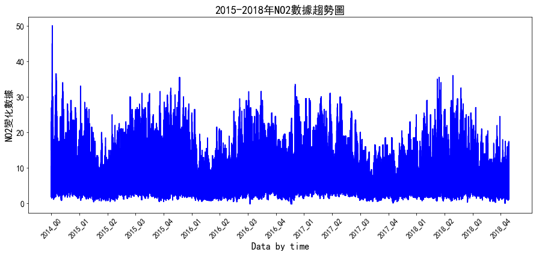

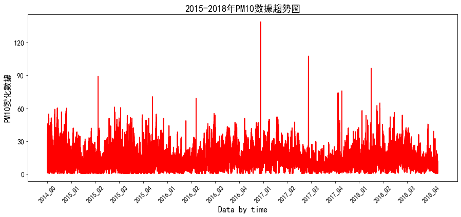

[output not shown]

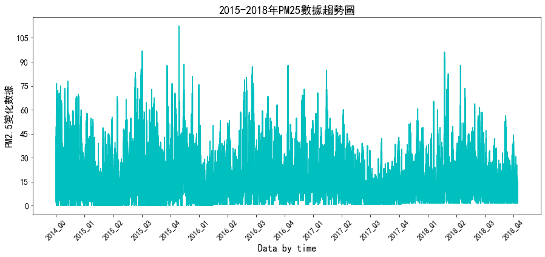

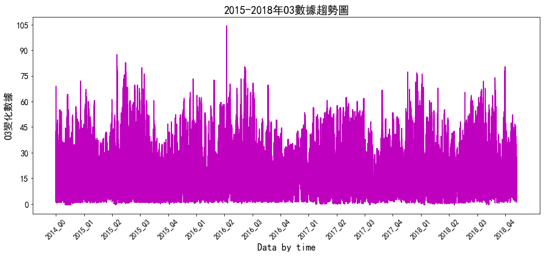

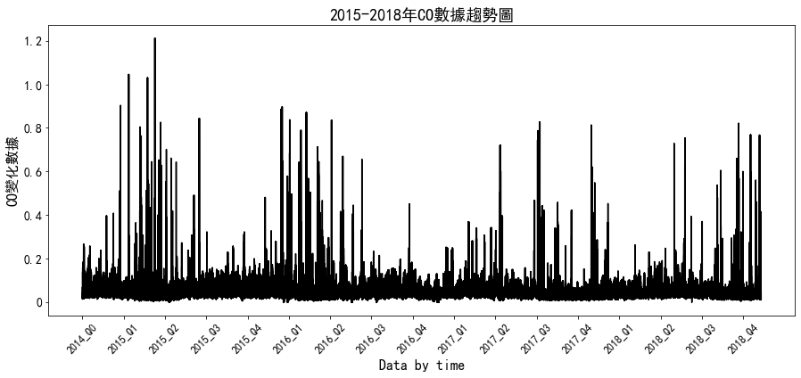

```python
import os
os.chdir(r'C:\Users\user\Desktop\學業\空氣品質\林佳龍時期')
os.getcwd()

import pandas as pd
df = pd.read_excel("2014年8月-2018年8月台中國家空氣品質測站整理2.xlsx")#引入整理過的資料檔
#SO2、NO2、PM10、PM2.5、O3、CO
#2015-2018年SO2數據趨勢圖
import numpy as np
import matplotlib.pyplot as plt
plt.rcParams['font.sans-serif']=['SimHei'] #顯示中文
SO2 = df.SO2.dropna()#Y軸的數據
data_by_time = np.arange(len(df.SO2.dropna()))#X軸的數據
plt.figure(figsize=(15,6)) #指定圖形大小
plt.plot(data_by_time,SO2,'y-')#x軸與y軸的呈現
plt.title("2015-2018年SO2數據趨勢圖",fontsize=18) #顯示標題
plt.xlabel("Data by time",fontsize=16) #顯示x軸標籤
plt.ylabel("SO2變化數據",fontsize=16) #顯示y軸標籤
plt.xticks([0,
            21850,43750,65625,87500,109375,131250,153125,175000,
            196875,218750,240625,262500,284375,306250,328125,350000],
           [r'2014_Q0',
            r'2015_Q1',r'2015_Q2','2015_Q3','2015_Q4',
            r'2016_Q1',r'2016_Q2','2016_Q3','2016_Q4',
            r'2017_Q1',r'2017_Q2','2017_Q3','2017_Q4',
            r'2018_Q1',r'2018_Q2','2018_Q3','2018_Q4'],rotation=45,fontsize=12) #X軸的數據以季度來取代
plt.yticks([0, 20, 40, 60, 80],
    [r'0', r'2', r'4',r'6',r'8'],fontsize=14) #Y軸的數據以符合其大小的數字間距取代
plt.show()#顯示整個圖表

#2015-2018年NO2數據趨勢圖
import numpy as np
import matplotlib.pyplot as plt
plt.rcParams['font.sans-serif']=['SimHei'] #顯示中文
NO2 = df.NO2.dropna()#Y軸的數據
data_by_time = np.arange(len(df.NO2.dropna()))#X軸的數據
plt.figure(figsize=(15,6)) #指定圖形大小
plt.plot(data_by_time,NO2,'b-')#x軸與y軸的呈現
plt.title("2015-2018年NO2數據趨勢圖",fontsize=18)
plt.xlabel("Data by time",fontsize=16)#顯示x軸標籤
plt.ylabel("NO2變化數據",fontsize=16)#顯示y軸標籤
plt.xticks([0,
            21850,43750,65625,87500,109375,131250,153125,175000,
            196875,218750,240625,262500,284375,306250,328125,350000],
           [r'2014_Q0',
            r'2015_Q1',r'2015_Q2','2015_Q3','2015_Q4',
            r'2016_Q1',r'2016_Q2','2016_Q3','2016_Q4',
            r'2017_Q1',r'2017_Q2','2017_Q3','2017_Q4',
            r'2018_Q1',r'2018_Q2','2018_Q3','2018_Q4'],rotation=45,fontsize=12) #X軸的數據以季度來取代
plt.yticks([0, 20, 40, 60, 80, 100],
    [r'0', r'10', r'20',r'30',r'40',r'50'],fontsize=14) #Y軸的數據以符合其大小的數字間距取代
plt.show()#顯示整個圖表

#2015-2018年PM10數據趨勢圖
import numpy as np
import matplotlib.pyplot as plt
plt.rcParams['font.sans-serif']=['SimHei'] #顯示中文
PM10 = df.PM10.dropna()#Y軸的數據
data_by_time = np.arange(len(df.PM10.dropna()))#X軸的數據
plt.figure(figsize=(15,6)) #指定圖形大小
plt.plot(data_by_time,PM10,'r-')#x軸與y軸的呈現
plt.title("2015-2018年PM10數據趨勢圖",fontsize=18)
plt.xlabel("Data by time",fontsize=16)#顯示x軸標籤
plt.ylabel("PM10變化數據",fontsize=16)#顯示y軸標籤
plt.xticks([0,
            21850,43750,65625,87500,109375,131250,153125,175000,
            196875,218750,240625,262500,284375,306250,328125,350000],
           [r'2014_Q0',
            r'2015_Q1',r'2015_Q2','2015_Q3','2015_Q4',
            r'2016_Q1',r'2016_Q2','2016_Q3','2016_Q4',
            r'2017_Q1',r'2017_Q2','2017_Q3','2017_Q4',
            r'2018_Q1',r'2018_Q2','2018_Q3','2018_Q4'],rotation=45,fontsize=12) #X軸的數據以季度來取代
plt.yticks([0, 100, 200, 300, 400],
    [r'0', r'30', r'60',r'90',r'120'],fontsize=14) #指定Y軸的顯示數值要由那些數字取代
plt.show()#顯示整個圖表

#2015-2018年PM2.5數據趨勢圖
import numpy as np
import matplotlib.pyplot as plt
plt.rcParams['font.sans-serif']=['SimHei'] #顯示中文
PM25 = df.PM25.dropna()#Y軸的數據
data_by_time = np.arange(len(df.PM25.dropna()))#X軸的數據
plt.figure(figsize=(15,6)) #指定圖形大小
plt.plot(data_by_time,PM25,'c-')#x軸與y軸的呈現
plt.title("2015-2018年PM25數據趨勢圖",fontsize=18)
plt.xlabel("Data by time",fontsize=16)#顯示x軸標籤
plt.ylabel("PM2.5變化數據",fontsize=16)#顯示y軸標籤
plt.xticks([0,
            21850,43750,65625,87500,109375,131250,153125,175000,
            196875,218750,240625,262500,284375,306250,328125,350000],
           [r'2014_Q0',
            r'2015_Q1',r'2015_Q2','2015_Q3','2015_Q4',
            r'2016_Q1',r'2016_Q2','2016_Q3','2016_Q4',
            r'2017_Q1',r'2017_Q2','2017_Q3','2017_Q4',
            r'2018_Q1',r'2018_Q2','2018_Q3','2018_Q4'],rotation=45,fontsize=12) #指定X軸的顯示數值要由那些數字取代
plt.yticks([0, 20, 40, 60, 80, 100, 120, 140],
    [r'0', r'15', r'30',r'45',r'60',r'75',r'90',r'105'],fontsize=14) #指定Y軸的顯示數值要由那些數字取代

#2015-2018年O3數據趨勢圖
import numpy as np
import matplotlib.pyplot as plt
plt.rcParams['font.sans-serif']=['SimHei'] #顯示中文
O3 = df.O3.dropna() #Y軸的數據
data_by_time = np.arange(len(df.O3.dropna())) #X軸的數據
plt.figure(figsize=(15,6)) #指定圖形大小
plt.plot(data_by_time,O3,'m-') #x軸與y軸的呈現
plt.title("2015-2018年O3數據趨勢圖",fontsize=18)
plt.xlabel("Data by time",fontsize=16) #顯示x軸標籤
plt.ylabel("O3變化數據",fontsize=16) #顯示y軸標籤
plt.xticks([0,
            21850,43750,65625,87500,109375,131250,153125,175000,
            196875,218750,240625,262500,284375,306250,328125,350000],
           [r'2014_Q0',
            r'2015_Q1',r'2015_Q2','2015_Q3','2015_Q4',
            r'2016_Q1',r'2016_Q2','2016_Q3','2016_Q4',
            r'2017_Q1',r'2017_Q2','2017_Q3','2017_Q4',
            r'2018_Q1',r'2018_Q2','2018_Q3','2018_Q4'],rotation=45,fontsize=12)#X軸的數據以季度來取代
plt.yticks([0, 25, 50, 75, 100, 125, 150, 175],
    [r'0', r'15', r'30',r'45',r'60',r'75',r'90',r'105'],fontsize=14) #指定Y軸的顯示數值要由那些數字取代

#2015-2018年CO數據趨勢圖
import numpy as np
import matplotlib.pyplot as plt
plt.rcParams['font.sans-serif']=['SimHei'] #顯示中文
CO = df.CO.dropna()#Y軸的數據
data_by_time = np.arange(len(df.CO.dropna()))#X軸的數據
plt.figure(figsize=(15,6)) #指定圖形大小
plt.plot(data_by_time,CO,'k-')#x軸與y軸的呈現
plt.title("2015-2018年CO數據趨勢圖",fontsize=18)
plt.xlabel("Data by time",fontsize=16)#顯示x軸標籤
plt.ylabel("CO變化數據",fontsize=16)#顯示y軸標籤
plt.xticks([0,
            21850,43750,65625,87500,109375,131250,153125,175000,
            196875,218750,240625,262500,284375,306250,328125,350000],
           [r'2014_Q0',
            r'2015_Q1',r'2015_Q2','2015_Q3','2015_Q4',
            r'2016_Q1',r'2016_Q2','2016_Q3','2016_Q4',
            r'2017_Q1',r'2017_Q2','2017_Q3','2017_Q4',
            r'2018_Q1',r'2018_Q2','2018_Q3','2018_Q4'],rotation=45,fontsize=12) #X軸的數據以季度來取代
plt.yticks([0, 2, 4, 6, 8, 10 ,12],
    [r'0', r'0.2', r'0.4',r'0.6',r'0.8',r'1.0',r'1.2'],fontsize=14) #指定Y軸的顯示數值要由那些數字取代
```

## 分析報告：

1. 以上分析為數據從2015-2018年的數據趨勢。
2. 以下一起提供平均值： SO2:"2.7ppb"、NO2:"15ppb"、PM10:"43.09μg/m3"、PM2.5:"21.85μg/m3"、O3:"29.07ppb"、CO:"0.4ppm"

SO2有微幅增加的趨勢，且單日排放值有增加的趨勢。 PM2.5、NO2則有隨著季節下降的趨勢。 PM10也同樣隨著時間有降低的區勢，但降低的幅度不大。 CO的單次最大量次數降低，最大量的日子也有較為稀疏的趨勢。

最值得探究的是，在每一季度間都有季節性的週期升降，且隨著季節的遞嬗而有各樣數據的呈現。若經由交叉比對，或許能得到各汙染數據間的相關性。

# 8.五個測站分別代表臺中的山海屯與市區，其中懸浮微粒PM2.5的數據高低是否與環境有關？

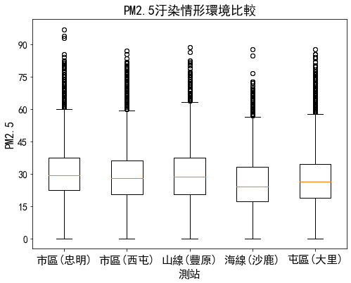

```python
import os
os.chdir(r'C:\Users\user\Desktop\學業\空氣品質\林佳龍時期')
os.getcwd()
%matplotlib inline
import pandas as pd
df = pd.read_excel("2014年8月-2018年8月台中國家空氣品質測站整理2.xlsx").dropna()
import matplotlib.pyplot as plt
plt.rcParams['font.sans-serif']=['SimHei'] #顯示中文
plt.figure(figsize=(8,6))
city = df[df["SITEID"].isin(["246"])] #指定246、247兩個測站的資料
city_pm25 = city.PM25 #市區的pm2.5值
city1 = df[df["SITEID"].isin(["247"])] #指定246、247兩個測站的資料
city1_pm25 = city1.PM25 #市區的pm2.5值
mountain = df[df["SITEID"].isin(["243"])] #指定測站243的資料
mountain_pm25 = mountain.PM25 #山線的pm2.5值
ocean = df[df["SITEID"].isin(["244"])] #指定測站244的資料
ocean_pm25 = ocean.PM25 #海線的pm2.5值
field = df[df["SITEID"].isin(["245"])] #指定測站245的資料
field_pm25 = field.PM25 #屯區的pm2.5值

all_data = [city_pm25, city1_pm25, mountain_pm25, ocean_pm25, field_pm25]
labels = ['市區(忠明)','市區(西屯)','山線(豐原)', '海線(沙鹿)', '屯區(大里)']
plt.boxplot(all_data,labels=labels)
plt.title('PM2.5汙染情形環境比較',fontsize=18)
plt.xlabel("測站",fontsize=16)
plt.ylabel("PM2.5",fontsize=16)
plt.yticks([0, 20, 40, 60, 80, 100, 120],
           [r'0', r'15', r'30',r'45',r'60',r'75',r'90'],fontsize=14) #調整X軸顯示的數值
plt.xticks(fontsize=16)
plt.show()
```

## 答:

此圖可以說明離群值的異常可能與其他因素有關，可揣測是汙染氣體個別排放日。

山線（豐原測站）的數據，百分位距的最大，在四類型的測站中箱型大小居首，可以推知其周邊的產業型態可能在平日汙染較大。

# 9. 山海屯市區的五支測站周圍是否有汙染工廠，如焚化廠、火力發電廠？

```python
#以下是測站的經緯度
feng_yuan = [24.2566, 120.7417]
sha_lu = [24.2256, 120.5688]
da_li = [24.0996, 120.6777]
zhong_ming = [24.152, 120.6411]
xi_tun = [24.1622, 120.6169]

#以下是汙染源的經緯度
taichung_fa_dian_chang = [24.214648, 120.492109]
taichung_gon_ye_qu = [24.171854, 120.600651]
taichung_le_se_fen_hua_lu = [24.151982, 120.600515]
xi_tun_gon_ye_qu = [24.175481, 120.656956]
da_li_gon_ye_qu = [24.106107, 120.714964]
houli_ziyuan_huishouchang = [24.289129, 120.698467]


import folium
fmap = folium.Map(location=xi_tun,tiles='stamentoner',control_scale = True, zoom_start=10)#設定進入地圖的起始點

fmap.add_child(folium.Marker(location=taichung_fa_dian_chang, #指定台中發電廠的經緯度
                   popup='台中發電廠', #點擊顯示標籤
                   icon=folium.Icon(icon='info-sign', #指定Icon類型
                                    color='red'))) # 使用Font Awesome Icons

fmap.add_child(folium.Marker(location=taichung_gon_ye_qu, #指定台中工業區的經緯度
                   popup='台中工業區', #點擊顯示標籤
                   icon=folium.Icon(icon='info-sign', #指定Icon類型
                                    color='red'))) #指定標籤顏色

fmap.add_child(folium.Marker(location=taichung_le_se_fen_hua_lu, #指定台中垃圾焚化爐的經緯度
                   popup='台中垃圾焚化廠', #點擊顯示標籤
                   icon=folium.Icon(icon='info-sign', #指定Icon類型
                                    color='red'))) #指定標籤顏色

fmap.add_child(folium.Marker(location=xi_tun_gon_ye_qu, #指定台中西屯工業區的經緯度
                   popup='西屯工業區', #點擊顯示標籤
                   icon=folium.Icon(icon='info-sign', #指定Icon類型
                                    color='red'))) #指定標籤顏色
fmap.add_child(folium.Marker(location=da_li_gon_ye_qu, #指定大里工業區的經緯度
                   popup='大里工業區', #點擊顯示標籤
                   icon=folium.Icon(icon='info-sign', #指定Icon類型
                                    color='red'))) #指定標籤顏色
fmap.add_child(folium.Marker(location=houli_ziyuan_huishouchang, #指定后里資源回收廠的經緯度
                   popup='后里資源回收廠', #點擊顯示標籤
                   icon=folium.Icon(icon='info-sign', #指定Icon類型
                                    color='red'))) #指定標籤顏色

fmap.add_child(folium.Circle(location=feng_yuan,#指定豐原測站的經緯度
                             color='green', # Circle 顏色
                             radius=3000, # Circle 寬度
                             popup='feng_yuan243', # 彈出視窗內容
                             fill=True, # 填滿中間區域
                             fill_opacity=0.1 # 設定透明度
                             ))
fmap.add_child(folium.Circle(location=sha_lu, #指定沙鹿測站的經緯度
                             color='red', # Circle 顏色
                             radius=3000, # Circle 寬度
                             popup='sha_lu244', # 彈出視窗內容
                             fill=True, # 填滿中間區域
                             fill_opacity=0.1 # 設定透明度
                             ))
fmap.add_child(folium.Circle(location=da_li, #指定大里測站的經緯度
                             color='blue', # Circle 顏色
                             radius=3000, # Circle 寬度
                             popup='da_li245', # 彈出視窗內容
                             fill=True, # 填滿中間區域
                             fill_opacity=0.1 # 設定透明度
                             ))
fmap.add_child(folium.Circle(location=zhong_ming, #指定忠明測站的經緯度
                             color='yellow', # Circle 顏色
                             radius=3000, # Circle 寬度
                             popup='zhong_ming246', # 彈出視窗內容
                             fill=True, # 填滿中間區域
                             fill_opacity=0.1 # 設定透明度
                             ))
fmap.add_child(folium.Circle(location=xi_tun, #指定西屯測站的經緯度
                             color='grey', # Circle 顏色
                             radius=3000, # Circle 寬度
                             popup='xi_tun247', # 彈出視窗內容
                             fill=True, # 填滿中間區域
                             fill_opacity=0.1 # 設定透明度
                             ))
```

[interactive chart not shown]

## 答:

# 10.據箱型圖顯示，山線豐原測站與海線沙鹿測站在數據上有差異，而豐原的PM2.5汙染程度卻比沙鹿值高，試比較其他汙染物在這兩個測站上的數據差異。

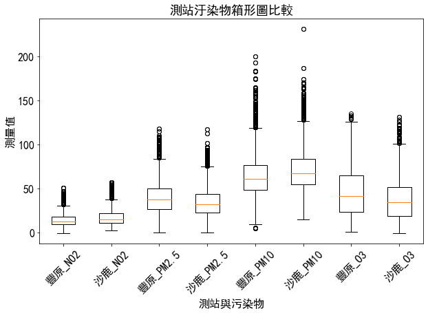

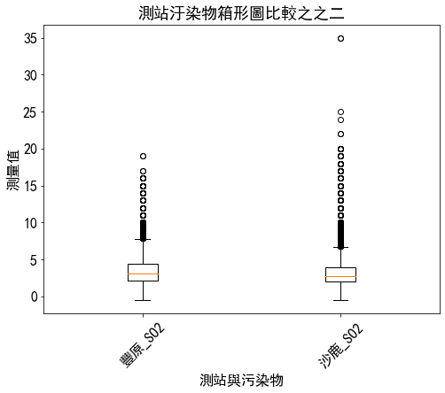

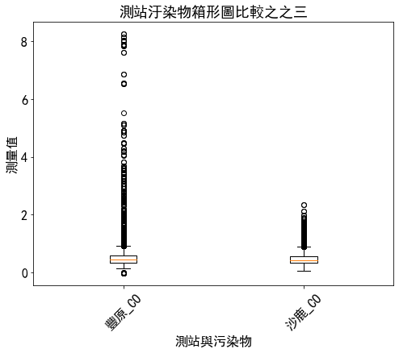

```python
#SO2:y、NO2:b、PM10:r、PM25:c、O3:m、CO:k
#先討論總量，這個測站跟其他測站的排放量有何差距？
#依箱型圖的概念
import os
os.chdir(r'C:\Users\user\Desktop\學業\空氣品質\林佳龍時期')
os.getcwd()
import pandas as pd
df = pd.read_excel("2014年8月-2018年8月台中國家空氣品質測站整理2.xlsx").dropna()

mountain = df[df["SITEID"].isin(["243"])] #指定測站243的資料
condition1 = np.arange(len(mountain.dropna()))#X軸的數據
mountain_SO2 = mountain.SO2 #山線的SO2值
mountain_NO2 = mountain.NO2 #山線的NO2值
mountain_PM10 = mountain.PM10 #山線的PM10值
mountain_PM25 = mountain.PM25 #山線的PM25值
mountain_O3 = mountain.O3 #山線的O3值
mountain_CO = mountain.CO #山線的CO值


ocean = df[df["SITEID"].isin(["244"])] #指定測站244的資料
condition2 = np.arange(len(ocean.dropna()))#X軸的數據
ocean_SO2 = ocean.SO2 #海線的SO2值
ocean_NO2 = ocean.NO2 #海線的NO2值
ocean_PM10 = ocean.PM10 #海線的PM10值
ocean_PM25 = ocean.PM25 #海線的PM25值
ocean_O3 = ocean.O3 #海線的O3值
ocean_CO = ocean.CO #海線的CO值

import matplotlib.pyplot as plt
plt.figure(figsize=(10,6))
all_data = [mountain_NO2, ocean_NO2,
            mountain_PM25, ocean_PM25,
            mountain_PM10, ocean_PM10,
            mountain_O3, ocean_O3]
labels = ['豐原_NO2','沙鹿_NO2',
          '豐原_PM2.5','沙鹿_PM2.5',
          '豐原_PM10', '沙鹿_PM10',
          '豐原_O3','沙鹿_O3']

plt.title('測站汙染物箱形圖比較',fontsize = 18) #標題，並指定字體大小
plt.boxplot(all_data,labels=labels) #箱型圖功能
plt.xlabel("測站與污染物",fontsize = 16)　#X軸的標籤
plt.ylabel("測量值",fontsize = 16) #Y軸的標籤
plt.xticks(fontsize = 16,rotation=45) #X軸的字體大小，以及旋轉45度
plt.yticks(fontsize=16)#用折線圖表達所有資料
plt.show()

#由於數值較小，為求顯示清楚，故以另一個圖顯示
import matplotlib.pyplot as plt
plt.figure(figsize=(8,6)) #指定圖的大小
all_data1 = [mountain_SO2, ocean_SO2] #數據
labels1 = ['豐原_SO2','沙鹿_SO2'] #標籤
plt.title('測站汙染物箱形圖比較之之二',fontsize = 18) #標題
plt.boxplot(all_data1,labels=labels1) #箱型圖功能
plt.xlabel("測站與污染物",fontsize = 16) #X軸的標籤
plt.ylabel("測量值",fontsize = 16) #Y軸的標籤
plt.xticks(fontsize = 16,rotation=45) #X軸的字體大小，並旋轉45度
plt.yticks(fontsize=16)#用折線圖表達所有資料
plt.show()

#由於數值較小，為求顯示清楚，故以另一個圖顯示
import matplotlib.pyplot as plt
plt.figure(figsize=(8,6))　#指定圖的大小
all_data2 = [mountain_CO, ocean_CO] #數據
labels2 = ['豐原_CO','沙鹿_CO'] #標籤
plt.title('測站汙染物箱形圖比較之之三',fontsize = 18) #標題
plt.boxplot(all_data2,labels=labels2) #箱型圖功能
plt.xlabel("測站與污染物",fontsize = 16) #X軸的標籤
plt.ylabel("測量值",fontsize = 16) #Y軸的標籤
plt.xticks(fontsize = 16,rotation=45) #X軸的字體大小，並旋轉45度
plt.yticks(fontsize=16)#用折線圖表達所有資料
plt.show()
```

# 答：

山線豐原測站與海線沙鹿測站在地理環境上有很大的不同，主要製造的汙染也不相同。

豐原測站附近有一座焚化爐：專門燒垃圾；沙鹿測站附近則是台中火力發電廠的進駐點，若要比較更多週邊的汙染，相較沙鹿測站，豐原附近的測站環繞著大小不等的工廠，有化工廠、能源工廠、機械工廠等，較易排放有機揮發物，所以臭氧汙染也相對嚴重，此處相較沙鹿的測站較高也是比較合理的解釋。

# 伍、研究結論

1.經濟與環境的二元宿命

空氣品質問題背後隱含的其實是經濟發展、環境保護的議題；當經濟發展成為地方顯著的現象時，同時環境議題就會隨之而來，經濟與環境兩個構面便會互相對抗；市民身為在大都市生活的集體，食衣住行大量依靠能源已是常態，若是減少能源的使用，生活的方便性就相對被限制，但若照顧了環境構面後，經濟發展問題又會成為我們必須面對的議題；而在經濟不景氣的時候，談環境問題只是隔靴搔癢。那在這兩個問題的輪流夾擊之下的政府應該如何解決面對呢？或許從合理的裁罰著手是一個方式，發展替代火力發電的其他能源也是一種方式。

2.政府、廠商、法律：

空氣汙染的數據中，排放日的汙染在市民的心中意味著對空氣的記憶。市民因此藉由空氣汙染評論政府未做好汙染的控管，然而汙染過量的產生並非單純來自廠商，而是在政府、廠商、法律三者之間遊走，但由法律制定的裁罰比例重嗎？對於中火來說，可能就是三日的業績如此。政府在發展經濟下又必須攏絡能源廠商，於是，環境保護政策如同一場騙局的成為政府立法與廠商圖利的循環。空氣汙染至今日的探討，也許只能減量，因為免不了經濟發展所需，但在此前提下應該怎麼制定排放標準，以及未及排放標準的合理裁罰，這才是問題所在。

3.能源設計方案與配套措施：不是從國外來的，就是適合的。

為了取代火力發電，台灣政府過去參考了國外的友善環境能源建設，將其學回國內並以政策施行，卻發現使用公帑後，這些貌似可以取代火力發電的能源供應來源其效益不如政府政策預期，甚至在維修費上就是一筆大數目。或許政府在興建相關設施之前，應該先評估台灣的大環境特色，設計適合的能源替代方案來進行改善與取代。